# individual1.Rmd

Taylor Turner

9/8/2020

```r
choco <- read.csv("https://raw.githubusercontent.com/xdaiISU/ds202materials/master/hwlabs/data/choco.csv")
str(choco)
```

```
## 'data.frame':    2312 obs. of  13 variables:
##  $ REF                 : int  2454 2458 2454 797 797 1015 1019 1011 1019 1011 ...
##  $ Company             : chr  "5150" "5150" "5150" "A. Morin" ...
##  $ Location            : chr  "U.S.A." "U.S.A." "U.S.A." "France" ...
##  $ Date                : int  2019 2019 2019 2012 2012 2013 2013 2013 2013 2013 ...
##  $ Bean_Origin         : chr  "Madagascar" "Dominican Republic" "Tanzania" "Peru" ...
##  $ Specific_Bean_Origin: chr  "Bejofo Estate, batch 1" "Zorzal, batch 1" "Kokoa Kamili, batch 1" "Peru" ...
##  $ Cocoa_Percent       : num  76 76 76 63 70 70 63 70 70 70 ...
##  $ Ingredients         : chr  "3- B,S,C" "3- B,S,C" "3- B,S,C" "4- B,S,C,L" ...
##  $ Characteristics1    : chr  "cocoa" "cocoa" "rich cocoa" "fruity" ...
##  $ Characteristics2    : chr  "blackberry" "vegetal" "fatty" "melon" ...
##  $ Characteristics3    : chr  "full body" "savory" "bready" "roasty" ...
##  $ Characteristics4    : chr  NA NA NA NA ...
##  $ Rating              : num  3.75 3.5 3.25 3.75 3.5 4 4 3.75 3.5 3.25 ...
```

1. As shown in the histogram and boxplot of the chocolate ratings, the ratings are fairly left skewed. Outliers in the data can be seen at ratings of 2.0, 1.75, 1.5, and 1.0.

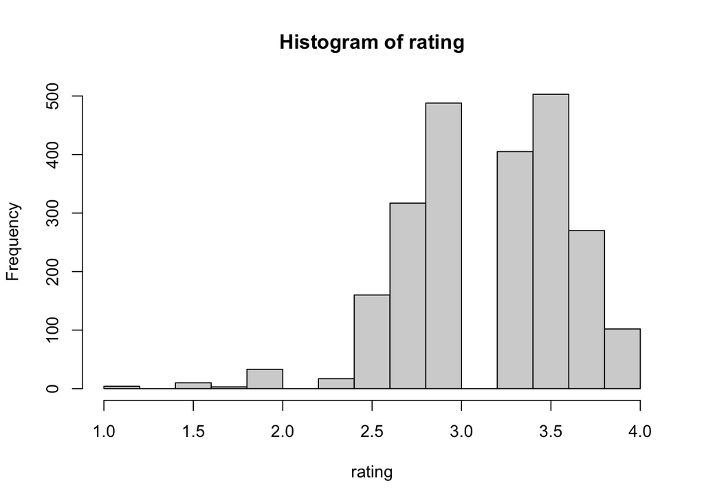

```r
rating <- choco$Rating
hist(rating)
```

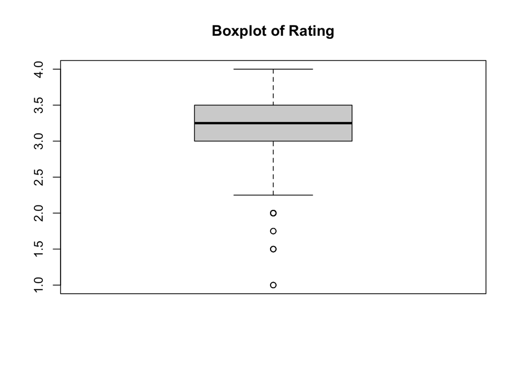

```r
boxplot(rating)
title(main="Boxplot of Rating")
```

2. It can be seen in the barplot that 2015 had the most ratings that year, while 2006 has the least. 2020 technically has the least, but I would argue that since 2020 is not yet over, that number is not definite yet.

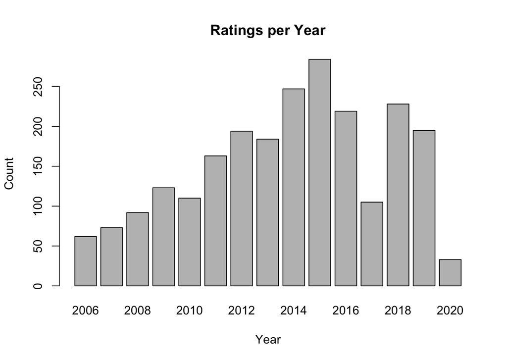

```r
barplot(table(choco$Date), c(2006:2020))
title(main="Ratings per Year", xlab="Year", ylab="Count")
```

3. From the scatterplot, there doesn’t seem to much of a correlation between cocoa percentage and rating. In general, cocoa percentages that are more mid-range rather than extreme seem to have higher ratings.

```r
percent <- choco[c("Cocoa_Percent","Rating")]
summary(percent)
```

```
##  Cocoa_Percent        Rating
##  Min.   : 42.00   Min.   :1.000
##  1st Qu.: 70.00   1st Qu.:3.000
##  Median : 70.00   Median :3.250
##  Mean   : 71.65   Mean   :3.184
##  3rd Qu.: 75.00   3rd Qu.:3.500
##  Max.   :100.00   Max.   :4.000
```

```r
str(percent)
```

```
## 'data.frame':    2312 obs. of  2 variables:
##  $ Cocoa_Percent: num  76 76 76 63 70 70 63 70 70 70 ...
##  $ Rating       : num  3.75 3.5 3.25 3.75 3.5 4 4 3.75 3.5 3.25 ...
```

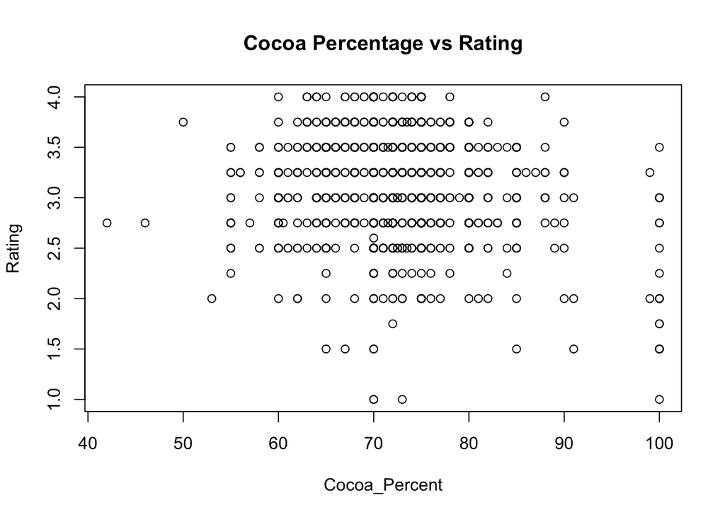

```r
plot(percent)
title(main="Cocoa Percentage vs Rating")
```

4. The most favorable characteristic is creamy, while the least favorable characteristics were acidic and pastey. I found these characteristics by first splitting the original dataframe into top tier and bottom tier, depending on their rating. I then plotted both of these new dataframes and found which characteristic was most frequent in both sets of data.

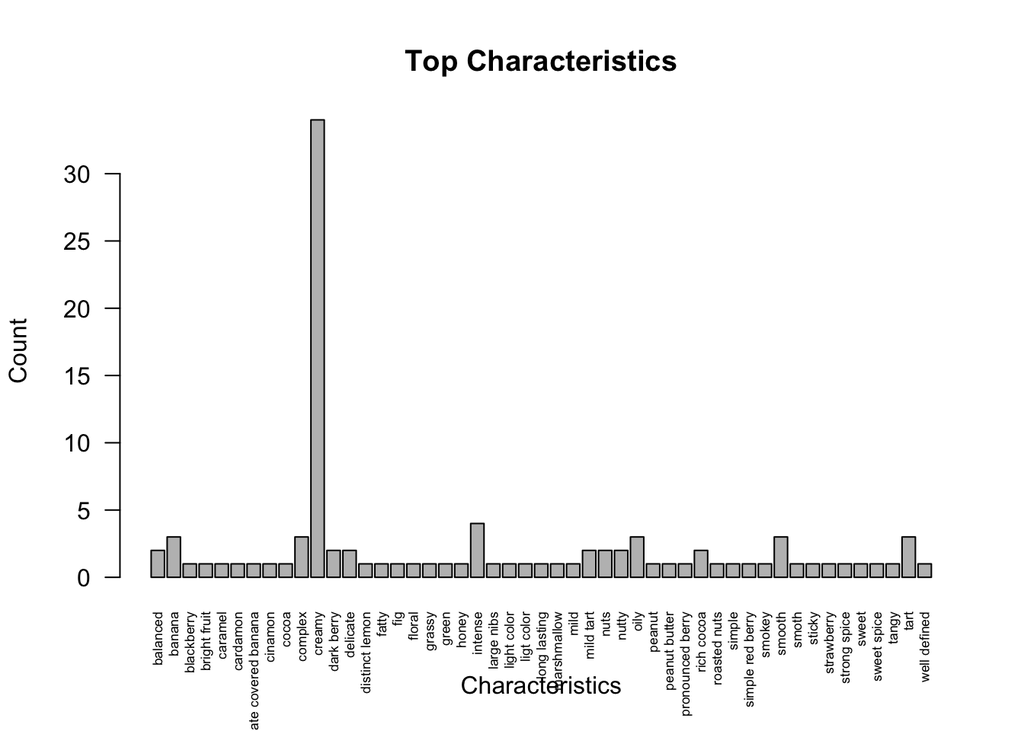

```r
flavor <- choco[c("Characteristics1", "Rating")]
topF <- flavor[flavor$Rating == 4, ]
barplot(table(topF$Characteristics1), las=2, cex.names=0.55)
title(main="Top Characteristics", xlab="Characteristics", ylab="Count")
```

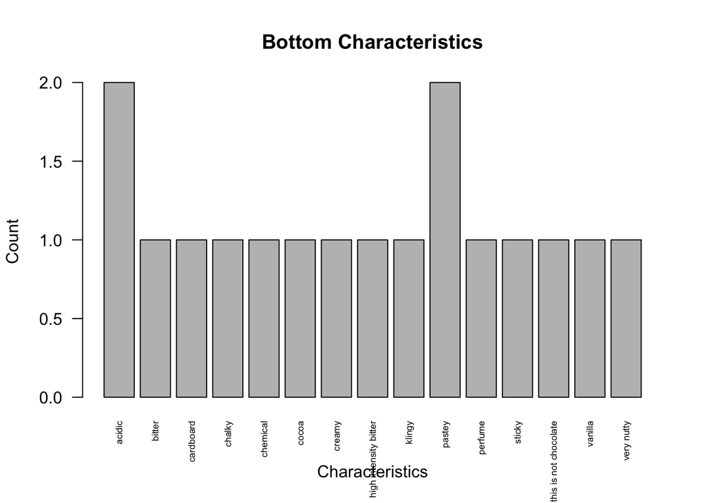

```r
bottomF <- flavor[flavor$Rating < 2, ]
barplot(table(bottomF$Characteristics1), las=2, cex.names=0.55)
title(main="Bottom Characteristics", xlab="Characteristics", ylab="Count")
```

```r
top_char <- sum(topF$Characteristics1 == 'creamy')
top_char
```

```
## [1] 34
```

```r
bottom_char1 <- sum(bottomF$Characteristics1 == 'acidic')
bottom_char1
```

```
## [1] 2
```

```r
bottom_char2 <- sum(bottomF$Characteristics1 == 'pastey')
bottom_char2
```

```
## [1] 2
```

5. The first analysis I made from this data is comparing the ratings of the chocolate to the bean origin and seeing which origin of bean gives the highest ratings. From my barplot, we can see that Venezuela has the most instances of 4.0 rating with 18 data entries. The second analysis I made was seeing which company had the most highest rated chocolate. From my analysis, we can see that the company “Soma” has the most counts of 4.0 rated chocolate.

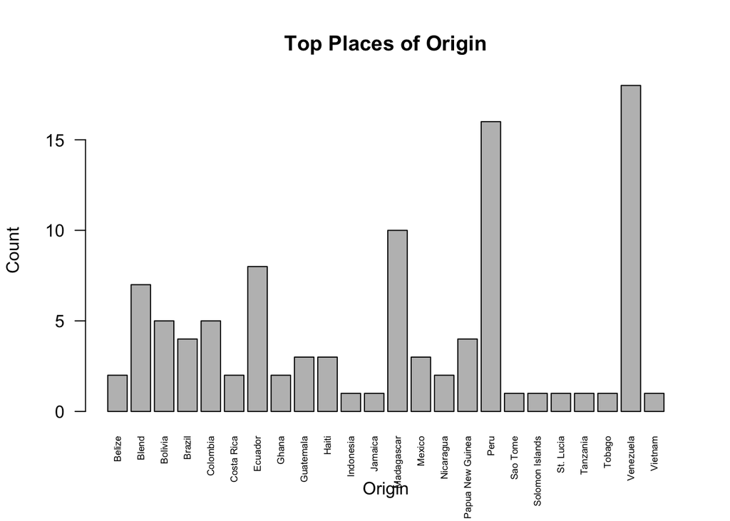

```r
origin <- choco[c("Bean_Origin", "Rating")]
topO <- origin[origin$Rating == 4,]
barplot(table(topO$Bean_Origin), las=2, cex.names=0.55)
title(main="Top Places of Origin", xlab="Origin", ylab="Count")
```

```r
top_origin <- sum(topO == 'Venezuela')
top_origin
```

```
## [1] 18
```

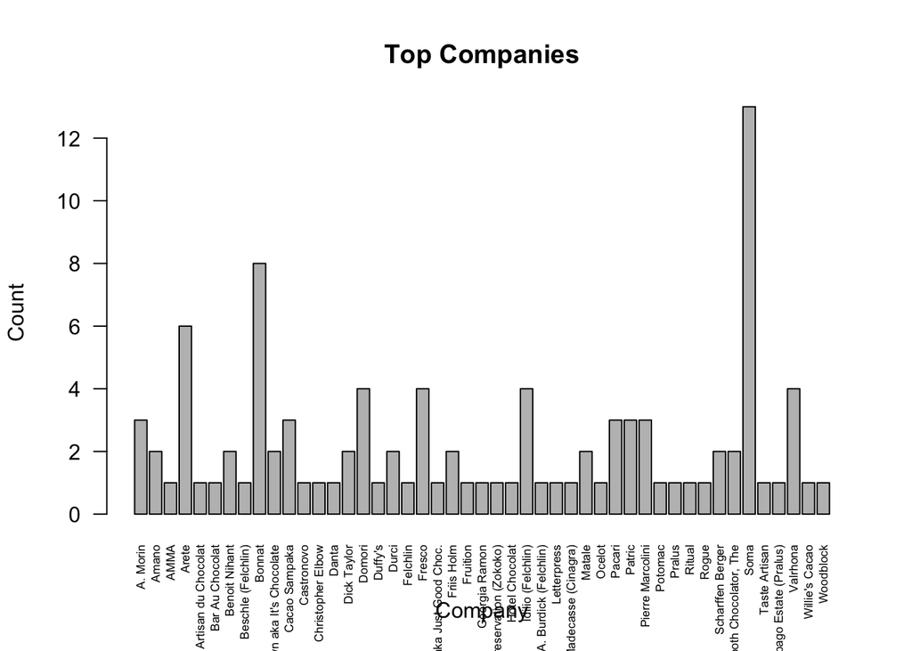

```r
company <- choco[c("Company", "Rating")]
topC <- company[company$Rating == 4,]
barplot(table(topC$Company), las=2, cex.names=0.55)
title(main="Top Companies", xlab="Company", ylab="Count")
```

```r
top_company <- sum(topC == 'Soma')
top_company
```

```
## [1] 13
```